[figure not shown]

# Workshop: Intro to R and R Studio

#### Data Analysis Team:

- Albina Gibadullina (GAA)
- Amir Michalovich (GAA)
- Jeremy Buhler (Data Librarian)
- Sarah Parker (Data Librarian)

# Land Acknowledgement

UBC is located on the traditional, ancestral, and unceded territory of the xʷməθkʷəy̓əm (Musqueam) people.

- Traditional: recognizes lands traditionally used and/or occupied by the Musqueam people or other First Nations in other parts of the country.
- Ancestral: recognizes land that is handed down from generation to generation.
- Unceded: refers to land that was not turned over to the Crown (government) by a treaty or other agreement.

Check out [native-land.ca](https://native-land.ca/) to see the interactive map of Indigenous territories around the world.

[figure not shown]

# Pre-workshop setup

#### Download and install R

*For Windows:*

1. Visit [R Project](https://www.r-project.org/) to learn about R versions.
2. Download and install R from your preferred CRAN mirror [here](https://cran.r-project.org/mirrors.html)
   1. Choose "0-Cloud" or a mirror site near you.

*For Mac:*

1. Check that your macOS system is up-to-date
2. Download and install R from [The Comprehensive R Archive Network](https://cran.r-project.org/)

#### Download and install R studio

*For Windows and Mac:*

1. Download and install R Studio from [here](https://rstudio.com/products/rstudio/download/#download)

# Learning Objectives

- Become familiar with R and R studio environment.
- Learn the basic R programming language.
- Learn how to explore data in R.

# R vs. R Studio

- **R** is a programming language. We use R to run our codes and see their output.
- **R Studio** is another program which manages R in a user-friendly environment.

That is why, it is highly recommended to install both programs because they work together.

# R Studio Environment

- Open R studio
- To create a new R script, click File > New file > R Script

[figure not shown]

# Working Directory

- Working directory is a folder/path where R reads and saves files.

#### Check your current working directory

- To check your current working directory, write and run `getwd()` in the console.

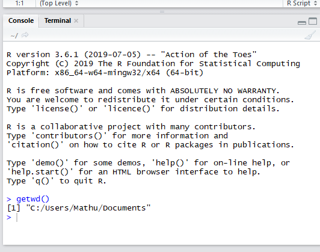

#### Set or Change your current working directory

[figure not shown]

- If you know the filepath to your new working directory, you can also write and run `setwd(dir)` in the console.

# Data Input

#### Data types and structures

There are different types of data that can be stored in R. In many cases, our data is organized and stored as DataFrame.

A DataFrame:

| Character | Numeric | Factor |
| --- | --- | --- |
| A | 1 | High |
| B | 2 | Medium |
| C | 3 | Low |

- Has multiple columns and rows
- Contains different types of variables
  - Numeric variables: numeric values with and without decimal places
  - Categorical variables: qualitative data that can be represented by characters or factors

# Basic R commands

An operator is a symbol that intructs R to perform specific operation. Here are some basic operators which can be used in R:

#### Mathematical operations

Description: This allows R to perform methematics operations.

| Operator | Description |
| --- | --- |
| + | Addition |
| - | Subtraction |
| * | Multiplication |
| / | Division |
| <- or = | Assign value from the right to the left |

#### Relational operations

Description: This allows R to compare variables.

| Operator | Description |
| --- | --- |
| == | Equal to |
| != | Not Equal to |
| > | Great than |
| < | Less than |
| >= | Great than or equal to |
| <= | Less than or equal to |

# Exercise #1

#### Calculate

- 1+1
- 4-9
- 19/3
- 14*6
- 4^3

#### Assign values to variables

- a <- 4
- a
- b <- 5
- b

Question: What do you notice in the Environment pane?

#### Calculate

- c <- 6 + a
- c
- d <- a + b + c
- d
- c==d

# Getting Started

#### R package

R package is a library of prewritten code designed for a particular task or a collection of tasks. For today, we will mainly use 'dplyr' and 'ggplot2'.

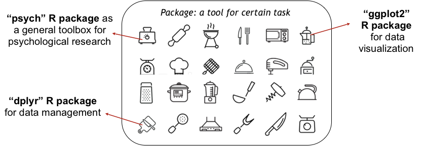

#### Installing a new package

There are three options to install a new package.

1. Under Tools -> Install Package -> Search for “dplyr”, “ggplot2”, and "gapminder"

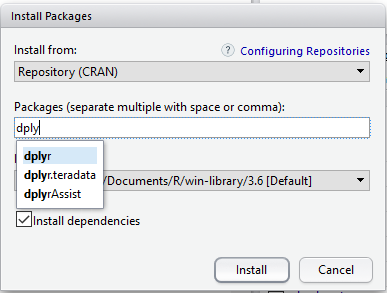

2. In Packages Tab (bottom right corner) -> Install -> Search for “dplyr”, “ggplot2”, and "gapminder" -> Install

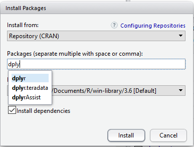

3. Write and run the following codes:

install.packages("dplyr")

install.packages("gglot2")

install.packages("gapminder")

# Loading installed packages

```r
# Use the library command to load any installed packages.

library(dplyr)

library(ggplot2)

library(gapminder)
```

Execute this code to check the description of the dataset

?gapminder

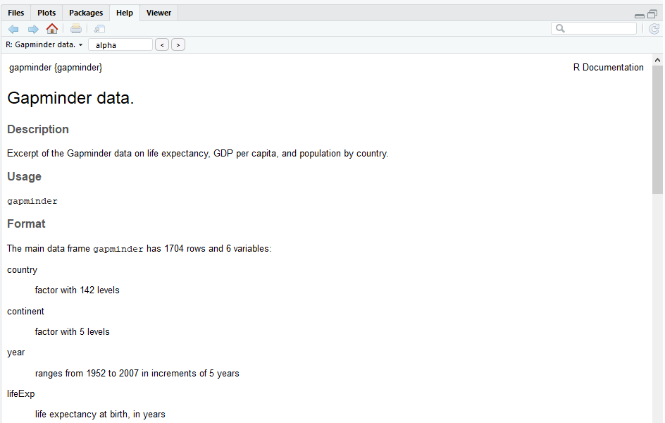

# Importing data from built-in R datasets

```r
# Import data from the built-in "gapminder" dataset

countries <- gapminder
head(countries) #see the first six rows of the dataframe
```

A tibble: 6 × 6

| country <fct> | continent <fct> | year <int> | lifeExp <dbl> | pop <int> | gdpPercap <dbl> |
| --- | --- | --- | --- | --- | --- |
| Afghanistan | Asia | 1952 | 28.801 | 8425333 | 779.4453 |
| Afghanistan | Asia | 1957 | 30.332 | 9240934 | 820.8530 |
| Afghanistan | Asia | 1962 | 31.997 | 10267083 | 853.1007 |
| Afghanistan | Asia | 1967 | 34.020 | 11537966 | 836.1971 |
| Afghanistan | Asia | 1972 | 36.088 | 13079460 | 739.9811 |
| Afghanistan | Asia | 1977 | 38.438 | 14880372 | 786.1134 |

How can you see the entire dataset?

View(countries)

[figure not shown]

```r
# How can you check the data structure?

str(countries)
```

```
tibble [1,704 × 6] (S3: tbl_df/tbl/data.frame)
 $ country  : Factor w/ 142 levels "Afghanistan",..: 1 1 1 1 1 1 1 1 1 1 ...
 $ continent: Factor w/ 5 levels "Africa","Americas",..: 3 3 3 3 3 3 3 3 3 3 ...
 $ year     : int [1:1704] 1952 1957 1962 1967 1972 1977 1982 1987 1992 1997 ...
 $ lifeExp  : num [1:1704] 28.8 30.3 32 34 36.1 ...
 $ pop      : int [1:1704] 8425333 9240934 10267083 11537966 13079460 14880372 12881816 13867957 16317921 22227415 ...
 $ gdpPercap: num [1:1704] 779 821 853 836 740 ...
```

```r
# Summarize the dataframe

summary(countries)
```

```
        country        continent        year         lifeExp
 Afghanistan:  12   Africa  :624   Min.   :1952   Min.   :23.60
 Albania    :  12   Americas:300   1st Qu.:1966   1st Qu.:48.20
 Algeria    :  12   Asia    :396   Median :1980   Median :60.71
 Angola     :  12   Europe  :360   Mean   :1980   Mean   :59.47
 Argentina  :  12   Oceania : 24   3rd Qu.:1993   3rd Qu.:70.85
 Australia  :  12                  Max.   :2007   Max.   :82.60
 (Other)    :1632
      pop              gdpPercap
 Min.   :6.001e+04   Min.   :   241.2
 1st Qu.:2.794e+06   1st Qu.:  1202.1
 Median :7.024e+06   Median :  3531.8
 Mean   :2.960e+07   Mean   :  7215.3
 3rd Qu.:1.959e+07   3rd Qu.:  9325.5
 Max.   :1.319e+09   Max.   :113523.1
```

```r
# Check if the dataframe is complete:

# Count the number of observations for each available year
table(countries$year)
```

```
1952 1957 1962 1967 1972 1977 1982 1987 1992 1997 2002 2007
 142  142  142  142  142  142  142  142  142  142  142  142
```

```r
# Count the number of observations in each continent for each available year

table(countries$continent, countries$year)
```

```
           1952 1957 1962 1967 1972 1977 1982 1987 1992 1997 2002 2007
  Africa     52   52   52   52   52   52   52   52   52   52   52   52
  Americas   25   25   25   25   25   25   25   25   25   25   25   25
  Asia       33   33   33   33   33   33   33   33   33   33   33   33
  Europe     30   30   30   30   30   30   30   30   30   30   30   30
  Oceania     2    2    2    2    2    2    2    2    2    2    2    2
```

#### Extra Info: Importing data from external data sources

*CSV data file*

- read.csv(file="countries.csv") # make sure the file is located in your working directory

*SPSS, SAS, or Stata data file*

- install.packages("foreign")
- library(foreign)
- read.spss() # SPSS
- read.dta() # Stata
- read.ssd() # SAS

# Data Manipulation with dplyr

# Using dplyr verbs to manage data

#### select ( )

- To selects columns based on columns names
- Useful when your data has many columns and you only need a subset of them

```r
# Select specific columns such as country, year, lifeExp

select(countries, country, year, lifeExp)
```

A tibble: 1704 × 3

| country <fct> | year <int> | lifeExp <dbl> |
| --- | --- | --- |
| Afghanistan | 1952 | 28.801 |
| Afghanistan | 1957 | 30.332 |
| Afghanistan | 1962 | 31.997 |
| Afghanistan | 1967 | 34.020 |
| Afghanistan | 1972 | 36.088 |
| Afghanistan | 1977 | 38.438 |
| Afghanistan | 1982 | 39.854 |
| Afghanistan | 1987 | 40.822 |
| Afghanistan | 1992 | 41.674 |
| Afghanistan | 1997 | 41.763 |
| Afghanistan | 2002 | 42.129 |
| Afghanistan | 2007 | 43.828 |
| Albania | 1952 | 55.230 |
| Albania | 1957 | 59.280 |
| Albania | 1962 | 64.820 |
| Albania | 1967 | 66.220 |
| Albania | 1972 | 67.690 |
| Albania | 1977 | 68.930 |
| Albania | 1982 | 70.420 |
| Albania | 1987 | 72.000 |
| Albania | 1992 | 71.581 |
| Albania | 1997 | 72.950 |
| Albania | 2002 | 75.651 |
| Albania | 2007 | 76.423 |
| Algeria | 1952 | 43.077 |
| Algeria | 1957 | 45.685 |
| Algeria | 1962 | 48.303 |
| Algeria | 1967 | 51.407 |
| Algeria | 1972 | 54.518 |
| Algeria | 1977 | 58.014 |
| ⋮ | ⋮ | ⋮ |
| Yemen, Rep. | 1982 | 49.113 |
| Yemen, Rep. | 1987 | 52.922 |
| Yemen, Rep. | 1992 | 55.599 |
| Yemen, Rep. | 1997 | 58.020 |
| Yemen, Rep. | 2002 | 60.308 |
| Yemen, Rep. | 2007 | 62.698 |
| Zambia | 1952 | 42.038 |
| Zambia | 1957 | 44.077 |
| Zambia | 1962 | 46.023 |
| Zambia | 1967 | 47.768 |
| Zambia | 1972 | 50.107 |
| Zambia | 1977 | 51.386 |
| Zambia | 1982 | 51.821 |
| Zambia | 1987 | 50.821 |
| Zambia | 1992 | 46.100 |
| Zambia | 1997 | 40.238 |
| Zambia | 2002 | 39.193 |
| Zambia | 2007 | 42.384 |
| Zimbabwe | 1952 | 48.451 |
| Zimbabwe | 1957 | 50.469 |
| Zimbabwe | 1962 | 52.358 |
| Zimbabwe | 1967 | 53.995 |
| Zimbabwe | 1972 | 55.635 |
| Zimbabwe | 1977 | 57.674 |
| Zimbabwe | 1982 | 60.363 |
| Zimbabwe | 1987 | 62.351 |
| Zimbabwe | 1992 | 60.377 |
| Zimbabwe | 1997 | 46.809 |
| Zimbabwe | 2002 | 39.989 |
| Zimbabwe | 2007 | 43.487 |

```r
# Select all columns except for continent and gdpPercap

select(countries, -continent, -gdpPercap) # use subtraction operator
```

A tibble: 1704 × 4

| country <fct> | year <int> | lifeExp <dbl> | pop <int> |
| --- | --- | --- | --- |
| Afghanistan | 1952 | 28.801 | 8425333 |
| Afghanistan | 1957 | 30.332 | 9240934 |
| Afghanistan | 1962 | 31.997 | 10267083 |
| Afghanistan | 1967 | 34.020 | 11537966 |
| Afghanistan | 1972 | 36.088 | 13079460 |
| Afghanistan | 1977 | 38.438 | 14880372 |
| Afghanistan | 1982 | 39.854 | 12881816 |
| Afghanistan | 1987 | 40.822 | 13867957 |
| Afghanistan | 1992 | 41.674 | 16317921 |
| Afghanistan | 1997 | 41.763 | 22227415 |
| Afghanistan | 2002 | 42.129 | 25268405 |
| Afghanistan | 2007 | 43.828 | 31889923 |
| Albania | 1952 | 55.230 | 1282697 |
| Albania | 1957 | 59.280 | 1476505 |
| Albania | 1962 | 64.820 | 1728137 |
| Albania | 1967 | 66.220 | 1984060 |
| Albania | 1972 | 67.690 | 2263554 |
| Albania | 1977 | 68.930 | 2509048 |
| Albania | 1982 | 70.420 | 2780097 |
| Albania | 1987 | 72.000 | 3075321 |
| Albania | 1992 | 71.581 | 3326498 |
| Albania | 1997 | 72.950 | 3428038 |
| Albania | 2002 | 75.651 | 3508512 |
| Albania | 2007 | 76.423 | 3600523 |
| Algeria | 1952 | 43.077 | 9279525 |
| Algeria | 1957 | 45.685 | 10270856 |
| Algeria | 1962 | 48.303 | 11000948 |
| Algeria | 1967 | 51.407 | 12760499 |
| Algeria | 1972 | 54.518 | 14760787 |
| Algeria | 1977 | 58.014 | 17152804 |
| ⋮ | ⋮ | ⋮ | ⋮ |
| Yemen, Rep. | 1982 | 49.113 | 9657618 |
| Yemen, Rep. | 1987 | 52.922 | 11219340 |
| Yemen, Rep. | 1992 | 55.599 | 13367997 |
| Yemen, Rep. | 1997 | 58.020 | 15826497 |
| Yemen, Rep. | 2002 | 60.308 | 18701257 |
| Yemen, Rep. | 2007 | 62.698 | 22211743 |
| Zambia | 1952 | 42.038 | 2672000 |
| Zambia | 1957 | 44.077 | 3016000 |
| Zambia | 1962 | 46.023 | 3421000 |
| Zambia | 1967 | 47.768 | 3900000 |
| Zambia | 1972 | 50.107 | 4506497 |
| Zambia | 1977 | 51.386 | 5216550 |
| Zambia | 1982 | 51.821 | 6100407 |
| Zambia | 1987 | 50.821 | 7272406 |
| Zambia | 1992 | 46.100 | 8381163 |
| Zambia | 1997 | 40.238 | 9417789 |
| Zambia | 2002 | 39.193 | 10595811 |
| Zambia | 2007 | 42.384 | 11746035 |
| Zimbabwe | 1952 | 48.451 | 3080907 |
| Zimbabwe | 1957 | 50.469 | 3646340 |
| Zimbabwe | 1962 | 52.358 | 4277736 |
| Zimbabwe | 1967 | 53.995 | 4995432 |
| Zimbabwe | 1972 | 55.635 | 5861135 |
| Zimbabwe | 1977 | 57.674 | 6642107 |
| Zimbabwe | 1982 | 60.363 | 7636524 |
| Zimbabwe | 1987 | 62.351 | 9216418 |
| Zimbabwe | 1992 | 60.377 | 10704340 |
| Zimbabwe | 1997 | 46.809 | 11404948 |
| Zimbabwe | 2002 | 39.989 | 11926563 |
| Zimbabwe | 2007 | 43.487 | 12311143 |

#### filter ( )

Filter rows based on conditions

```r
# Filter data of countries from 1997 and with Oceania continent

filter(countries, year==1997, continent=="Oceania")
```

A tibble: 2 × 6

| country <fct> | continent <fct> | year <int> | lifeExp <dbl> | pop <int> | gdpPercap <dbl> |
| --- | --- | --- | --- | --- | --- |
| Australia | Oceania | 1997 | 78.83 | 18565243 | 26997.94 |
| New Zealand | Oceania | 1997 | 77.55 | 3676187 | 21050.41 |

```r
# Filter data of countries from 2007 and with gdpPercap greater than $40,000

filter(countries, year==2007, gdpPercap>40000)
```

A tibble: 5 × 6

| country <fct> | continent <fct> | year <int> | lifeExp <dbl> | pop <int> | gdpPercap <dbl> |
| --- | --- | --- | --- | --- | --- |
| Ireland | Europe | 2007 | 78.885 | 4109086 | 40676.00 |
| Kuwait | Asia | 2007 | 77.588 | 2505559 | 47306.99 |
| Norway | Europe | 2007 | 80.196 | 4627926 | 49357.19 |
| Singapore | Asia | 2007 | 79.972 | 4553009 | 47143.18 |
| United States | Americas | 2007 | 78.242 | 301139947 | 42951.65 |

Question: What relational operator should you use for greater than and equal to $40,000?

```r
# Solution:

filter(countries, year==2007, gdpPercap>=40000)
```

A tibble: 5 × 6

| country <fct> | continent <fct> | year <int> | lifeExp <dbl> | pop <int> | gdpPercap <dbl> |
| --- | --- | --- | --- | --- | --- |
| Ireland | Europe | 2007 | 78.885 | 4109086 | 40676.00 |
| Kuwait | Asia | 2007 | 77.588 | 2505559 | 47306.99 |
| Norway | Europe | 2007 | 80.196 | 4627926 | 49357.19 |
| Singapore | Asia | 2007 | 79.972 | 4553009 | 47143.18 |
| United States | Americas | 2007 | 78.242 | 301139947 | 42951.65 |

```r
# Filter observations from year 2002 or year 2007

filter(countries, year==2002 | year==2007) # Use vertical line for Or condition
```

A tibble: 284 × 6

| country <fct> | continent <fct> | year <int> | lifeExp <dbl> | pop <int> | gdpPercap <dbl> |
| --- | --- | --- | --- | --- | --- |
| Afghanistan | Asia | 2002 | 42.129 | 25268405 | 726.7341 |
| Afghanistan | Asia | 2007 | 43.828 | 31889923 | 974.5803 |
| Albania | Europe | 2002 | 75.651 | 3508512 | 4604.2117 |
| Albania | Europe | 2007 | 76.423 | 3600523 | 5937.0295 |
| Algeria | Africa | 2002 | 70.994 | 31287142 | 5288.0404 |
| Algeria | Africa | 2007 | 72.301 | 33333216 | 6223.3675 |
| Angola | Africa | 2002 | 41.003 | 10866106 | 2773.2873 |
| Angola | Africa | 2007 | 42.731 | 12420476 | 4797.2313 |
| Argentina | Americas | 2002 | 74.340 | 38331121 | 8797.6407 |
| Argentina | Americas | 2007 | 75.320 | 40301927 | 12779.3796 |
| Australia | Oceania | 2002 | 80.370 | 19546792 | 30687.7547 |
| Australia | Oceania | 2007 | 81.235 | 20434176 | 34435.3674 |
| Austria | Europe | 2002 | 78.980 | 8148312 | 32417.6077 |
| Austria | Europe | 2007 | 79.829 | 8199783 | 36126.4927 |
| Bahrain | Asia | 2002 | 74.795 | 656397 | 23403.5593 |
| Bahrain | Asia | 2007 | 75.635 | 708573 | 29796.0483 |
| Bangladesh | Asia | 2002 | 62.013 | 135656790 | 1136.3904 |
| Bangladesh | Asia | 2007 | 64.062 | 150448339 | 1391.2538 |
| Belgium | Europe | 2002 | 78.320 | 10311970 | 30485.8838 |
| Belgium | Europe | 2007 | 79.441 | 10392226 | 33692.6051 |
| Benin | Africa | 2002 | 54.406 | 7026113 | 1372.8779 |
| Benin | Africa | 2007 | 56.728 | 8078314 | 1441.2849 |
| Bolivia | Americas | 2002 | 63.883 | 8445134 | 3413.2627 |
| Bolivia | Americas | 2007 | 65.554 | 9119152 | 3822.1371 |
| Bosnia and Herzegovina | Europe | 2002 | 74.090 | 4165416 | 6018.9752 |
| Bosnia and Herzegovina | Europe | 2007 | 74.852 | 4552198 | 7446.2988 |
| Botswana | Africa | 2002 | 46.634 | 1630347 | 11003.6051 |
| Botswana | Africa | 2007 | 50.728 | 1639131 | 12569.8518 |
| Brazil | Americas | 2002 | 71.006 | 179914212 | 8131.2128 |
| Brazil | Americas | 2007 | 72.390 | 190010647 | 9065.8008 |
| ⋮ | ⋮ | ⋮ | ⋮ | ⋮ | ⋮ |
| Thailand | Asia | 2002 | 68.564 | 62806748 | 5913.1875 |
| Thailand | Asia | 2007 | 70.616 | 65068149 | 7458.3963 |
| Togo | Africa | 2002 | 57.561 | 4977378 | 886.2206 |
| Togo | Africa | 2007 | 58.420 | 5701579 | 882.9699 |
| Trinidad and Tobago | Americas | 2002 | 68.976 | 1101832 | 11460.6002 |
| Trinidad and Tobago | Americas | 2007 | 69.819 | 1056608 | 18008.5092 |
| Tunisia | Africa | 2002 | 73.042 | 9770575 | 5722.8957 |
| Tunisia | Africa | 2007 | 73.923 | 10276158 | 7092.9230 |
| Turkey | Europe | 2002 | 70.845 | 67308928 | 6508.0857 |
| Turkey | Europe | 2007 | 71.777 | 71158647 | 8458.2764 |
| Uganda | Africa | 2002 | 47.813 | 24739869 | 927.7210 |
| Uganda | Africa | 2007 | 51.542 | 29170398 | 1056.3801 |
| United Kingdom | Europe | 2002 | 78.471 | 59912431 | 29478.9992 |
| United Kingdom | Europe | 2007 | 79.425 | 60776238 | 33203.2613 |
| United States | Americas | 2002 | 77.310 | 287675526 | 39097.0995 |
| United States | Americas | 2007 | 78.242 | 301139947 | 42951.6531 |
| Uruguay | Americas | 2002 | 75.307 | 3363085 | 7727.0020 |
| Uruguay | Americas | 2007 | 76.384 | 3447496 | 10611.4630 |
| Venezuela | Americas | 2002 | 72.766 | 24287670 | 8605.0478 |
| Venezuela | Americas | 2007 | 73.747 | 26084662 | 11415.8057 |
| Vietnam | Asia | 2002 | 73.017 | 80908147 | 1764.4567 |
| Vietnam | Asia | 2007 | 74.249 | 85262356 | 2441.5764 |
| West Bank and Gaza | Asia | 2002 | 72.370 | 3389578 | 4515.4876 |
| West Bank and Gaza | Asia | 2007 | 73.422 | 4018332 | 3025.3498 |
| Yemen, Rep. | Asia | 2002 | 60.308 | 18701257 | 2234.8208 |
| Yemen, Rep. | Asia | 2007 | 62.698 | 22211743 | 2280.7699 |
| Zambia | Africa | 2002 | 39.193 | 10595811 | 1071.6139 |
| Zambia | Africa | 2007 | 42.384 | 11746035 | 1271.2116 |
| Zimbabwe | Africa | 2002 | 39.989 | 11926563 | 672.0386 |
| Zimbabwe | Africa | 2007 | 43.487 | 12311143 | 469.7093 |

#### arrange ( )

Arrange rows by ascending or decending order

```r
# Arrange countries based on life expectancy (from smallest to largest)

arrange(countries, lifeExp)
```

A tibble: 1704 × 6

| country <fct> | continent <fct> | year <int> | lifeExp <dbl> | pop <int> | gdpPercap <dbl> |
| --- | --- | --- | --- | --- | --- |
| Rwanda | Africa | 1992 | 23.599 | 7290203 | 737.0686 |
| Afghanistan | Asia | 1952 | 28.801 | 8425333 | 779.4453 |
| Gambia | Africa | 1952 | 30.000 | 284320 | 485.2307 |
| Angola | Africa | 1952 | 30.015 | 4232095 | 3520.6103 |
| Sierra Leone | Africa | 1952 | 30.331 | 2143249 | 879.7877 |
| Afghanistan | Asia | 1957 | 30.332 | 9240934 | 820.8530 |
| Cambodia | Asia | 1977 | 31.220 | 6978607 | 524.9722 |
| Mozambique | Africa | 1952 | 31.286 | 6446316 | 468.5260 |
| Sierra Leone | Africa | 1957 | 31.570 | 2295678 | 1004.4844 |
| Burkina Faso | Africa | 1952 | 31.975 | 4469979 | 543.2552 |
| Afghanistan | Asia | 1962 | 31.997 | 10267083 | 853.1007 |
| Angola | Africa | 1957 | 31.999 | 4561361 | 3827.9405 |
| Gambia | Africa | 1957 | 32.065 | 323150 | 520.9267 |
| Guinea-Bissau | Africa | 1952 | 32.500 | 580653 | 299.8503 |
| Yemen, Rep. | Asia | 1952 | 32.548 | 4963829 | 781.7176 |
| Sierra Leone | Africa | 1962 | 32.767 | 2467895 | 1116.6399 |
| Somalia | Africa | 1952 | 32.978 | 2526994 | 1135.7498 |
| Guinea-Bissau | Africa | 1957 | 33.489 | 601095 | 431.7905 |
| Guinea | Africa | 1952 | 33.609 | 2664249 | 510.1965 |
| Mali | Africa | 1952 | 33.685 | 3838168 | 452.3370 |
| Mozambique | Africa | 1957 | 33.779 | 7038035 | 495.5868 |
| Gambia | Africa | 1962 | 33.896 | 374020 | 599.6503 |
| Yemen, Rep. | Asia | 1957 | 33.970 | 5498090 | 804.8305 |
| Angola | Africa | 1962 | 34.000 | 4826015 | 4269.2767 |
| Afghanistan | Asia | 1967 | 34.020 | 11537966 | 836.1971 |
| Ethiopia | Africa | 1952 | 34.078 | 20860941 | 362.1463 |
| Sierra Leone | Africa | 1967 | 34.113 | 2662190 | 1206.0435 |
| Equatorial Guinea | Africa | 1952 | 34.482 | 216964 | 375.6431 |
| Guinea-Bissau | Africa | 1962 | 34.488 | 627820 | 522.0344 |
| Guinea | Africa | 1957 | 34.558 | 2876726 | 576.2670 |
| ⋮ | ⋮ | ⋮ | ⋮ | ⋮ | ⋮ |
| Greece | Europe | 2007 | 79.483 | 10706290 | 27538.41 |
| France | Europe | 2002 | 79.590 | 59925035 | 28926.03 |
| Israel | Asia | 2002 | 79.696 | 6029529 | 21905.60 |
| Netherlands | Europe | 2007 | 79.762 | 16570613 | 36797.93 |
| Canada | Americas | 2002 | 79.770 | 31902268 | 33328.97 |
| Spain | Europe | 2002 | 79.780 | 40152517 | 24835.47 |
| Austria | Europe | 2007 | 79.829 | 8199783 | 36126.49 |
| Singapore | Asia | 2007 | 79.972 | 4553009 | 47143.18 |
| Hong Kong, China | Asia | 1997 | 80.000 | 6495918 | 28377.63 |
| Sweden | Europe | 2002 | 80.040 | 8954175 | 29341.63 |
| Norway | Europe | 2007 | 80.196 | 4627926 | 49357.19 |
| New Zealand | Oceania | 2007 | 80.204 | 4115771 | 25185.01 |
| Italy | Europe | 2002 | 80.240 | 57926999 | 27968.10 |
| Australia | Oceania | 2002 | 80.370 | 19546792 | 30687.75 |
| Iceland | Europe | 2002 | 80.500 | 288030 | 31163.20 |
| Italy | Europe | 2007 | 80.546 | 58147733 | 28569.72 |
| Switzerland | Europe | 2002 | 80.620 | 7361757 | 34480.96 |
| Canada | Americas | 2007 | 80.653 | 33390141 | 36319.24 |
| France | Europe | 2007 | 80.657 | 61083916 | 30470.02 |
| Japan | Asia | 1997 | 80.690 | 125956499 | 28816.58 |
| Israel | Asia | 2007 | 80.745 | 6426679 | 25523.28 |
| Sweden | Europe | 2007 | 80.884 | 9031088 | 33859.75 |
| Spain | Europe | 2007 | 80.941 | 40448191 | 28821.06 |
| Australia | Oceania | 2007 | 81.235 | 20434176 | 34435.37 |
| Hong Kong, China | Asia | 2002 | 81.495 | 6762476 | 30209.02 |
| Switzerland | Europe | 2007 | 81.701 | 7554661 | 37506.42 |
| Iceland | Europe | 2007 | 81.757 | 301931 | 36180.79 |
| Japan | Asia | 2002 | 82.000 | 127065841 | 28604.59 |
| Hong Kong, China | Asia | 2007 | 82.208 | 6980412 | 39724.98 |
| Japan | Asia | 2007 | 82.603 | 127467972 | 31656.07 |

```r
# Arrange countries based on life expectancy (from smallest to largest), sorted first by year (from earliest year available to most recent)

arrange(countries, year, lifeExp)
```

A tibble: 1704 × 6

| country <fct> | continent <fct> | year <int> | lifeExp <dbl> | pop <int> | gdpPercap <dbl> |
| --- | --- | --- | --- | --- | --- |
| Afghanistan | Asia | 1952 | 28.801 | 8425333 | 779.4453 |
| Gambia | Africa | 1952 | 30.000 | 284320 | 485.2307 |
| Angola | Africa | 1952 | 30.015 | 4232095 | 3520.6103 |
| Sierra Leone | Africa | 1952 | 30.331 | 2143249 | 879.7877 |
| Mozambique | Africa | 1952 | 31.286 | 6446316 | 468.5260 |
| Burkina Faso | Africa | 1952 | 31.975 | 4469979 | 543.2552 |
| Guinea-Bissau | Africa | 1952 | 32.500 | 580653 | 299.8503 |
| Yemen, Rep. | Asia | 1952 | 32.548 | 4963829 | 781.7176 |
| Somalia | Africa | 1952 | 32.978 | 2526994 | 1135.7498 |
| Guinea | Africa | 1952 | 33.609 | 2664249 | 510.1965 |
| Mali | Africa | 1952 | 33.685 | 3838168 | 452.3370 |
| Ethiopia | Africa | 1952 | 34.078 | 20860941 | 362.1463 |
| Equatorial Guinea | Africa | 1952 | 34.482 | 216964 | 375.6431 |
| Djibouti | Africa | 1952 | 34.812 | 63149 | 2669.5295 |
| Central African Republic | Africa | 1952 | 35.463 | 1291695 | 1071.3107 |
| Eritrea | Africa | 1952 | 35.928 | 1438760 | 328.9406 |
| Nepal | Asia | 1952 | 36.157 | 9182536 | 545.8657 |
| Malawi | Africa | 1952 | 36.256 | 2917802 | 369.1651 |
| Myanmar | Asia | 1952 | 36.319 | 20092996 | 331.0000 |
| Nigeria | Africa | 1952 | 36.324 | 33119096 | 1077.2819 |
| Madagascar | Africa | 1952 | 36.681 | 4762912 | 1443.0117 |
| Gabon | Africa | 1952 | 37.003 | 420702 | 4293.4765 |
| Senegal | Africa | 1952 | 37.278 | 2755589 | 1450.3570 |
| India | Asia | 1952 | 37.373 | 372000000 | 546.5657 |
| Niger | Africa | 1952 | 37.444 | 3379468 | 761.8794 |
| Indonesia | Asia | 1952 | 37.468 | 82052000 | 749.6817 |
| Bangladesh | Asia | 1952 | 37.484 | 46886859 | 684.2442 |
| Oman | Asia | 1952 | 37.578 | 507833 | 1828.2303 |
| Haiti | Americas | 1952 | 37.579 | 3201488 | 1840.3669 |
| Chad | Africa | 1952 | 38.092 | 2682462 | 1178.6659 |
| ⋮ | ⋮ | ⋮ | ⋮ | ⋮ | ⋮ |
| United States | Americas | 2007 | 78.242 | 301139947 | 42951.653 |
| Cuba | Americas | 2007 | 78.273 | 11416987 | 8948.103 |
| Denmark | Europe | 2007 | 78.332 | 5468120 | 35278.419 |
| Taiwan | Asia | 2007 | 78.400 | 23174294 | 28718.277 |
| Chile | Americas | 2007 | 78.553 | 16284741 | 13171.639 |
| Korea, Rep. | Asia | 2007 | 78.623 | 49044790 | 23348.140 |
| Puerto Rico | Americas | 2007 | 78.746 | 3942491 | 19328.709 |
| Costa Rica | Americas | 2007 | 78.782 | 4133884 | 9645.061 |
| Ireland | Europe | 2007 | 78.885 | 4109086 | 40675.996 |
| Finland | Europe | 2007 | 79.313 | 5238460 | 33207.084 |
| Germany | Europe | 2007 | 79.406 | 82400996 | 32170.374 |
| United Kingdom | Europe | 2007 | 79.425 | 60776238 | 33203.261 |
| Belgium | Europe | 2007 | 79.441 | 10392226 | 33692.605 |
| Greece | Europe | 2007 | 79.483 | 10706290 | 27538.412 |
| Netherlands | Europe | 2007 | 79.762 | 16570613 | 36797.933 |
| Austria | Europe | 2007 | 79.829 | 8199783 | 36126.493 |
| Singapore | Asia | 2007 | 79.972 | 4553009 | 47143.180 |
| Norway | Europe | 2007 | 80.196 | 4627926 | 49357.190 |
| New Zealand | Oceania | 2007 | 80.204 | 4115771 | 25185.009 |
| Italy | Europe | 2007 | 80.546 | 58147733 | 28569.720 |
| Canada | Americas | 2007 | 80.653 | 33390141 | 36319.235 |
| France | Europe | 2007 | 80.657 | 61083916 | 30470.017 |
| Israel | Asia | 2007 | 80.745 | 6426679 | 25523.277 |
| Sweden | Europe | 2007 | 80.884 | 9031088 | 33859.748 |
| Spain | Europe | 2007 | 80.941 | 40448191 | 28821.064 |
| Australia | Oceania | 2007 | 81.235 | 20434176 | 34435.367 |
| Switzerland | Europe | 2007 | 81.701 | 7554661 | 37506.419 |
| Iceland | Europe | 2007 | 81.757 | 301931 | 36180.789 |
| Hong Kong, China | Asia | 2007 | 82.208 | 6980412 | 39724.979 |
| Japan | Asia | 2007 | 82.603 | 127467972 | 31656.068 |

```r
# Arrange countries based on life expectancy (from largest to smallest)

arrange(countries, desc(lifeExp))
```

A tibble: 1704 × 6

| country <fct> | continent <fct> | year <int> | lifeExp <dbl> | pop <int> | gdpPercap <dbl> |
| --- | --- | --- | --- | --- | --- |
| Japan | Asia | 2007 | 82.603 | 127467972 | 31656.07 |
| Hong Kong, China | Asia | 2007 | 82.208 | 6980412 | 39724.98 |
| Japan | Asia | 2002 | 82.000 | 127065841 | 28604.59 |
| Iceland | Europe | 2007 | 81.757 | 301931 | 36180.79 |
| Switzerland | Europe | 2007 | 81.701 | 7554661 | 37506.42 |
| Hong Kong, China | Asia | 2002 | 81.495 | 6762476 | 30209.02 |
| Australia | Oceania | 2007 | 81.235 | 20434176 | 34435.37 |
| Spain | Europe | 2007 | 80.941 | 40448191 | 28821.06 |
| Sweden | Europe | 2007 | 80.884 | 9031088 | 33859.75 |
| Israel | Asia | 2007 | 80.745 | 6426679 | 25523.28 |
| Japan | Asia | 1997 | 80.690 | 125956499 | 28816.58 |
| France | Europe | 2007 | 80.657 | 61083916 | 30470.02 |
| Canada | Americas | 2007 | 80.653 | 33390141 | 36319.24 |
| Switzerland | Europe | 2002 | 80.620 | 7361757 | 34480.96 |
| Italy | Europe | 2007 | 80.546 | 58147733 | 28569.72 |
| Iceland | Europe | 2002 | 80.500 | 288030 | 31163.20 |
| Australia | Oceania | 2002 | 80.370 | 19546792 | 30687.75 |
| Italy | Europe | 2002 | 80.240 | 57926999 | 27968.10 |
| New Zealand | Oceania | 2007 | 80.204 | 4115771 | 25185.01 |
| Norway | Europe | 2007 | 80.196 | 4627926 | 49357.19 |
| Sweden | Europe | 2002 | 80.040 | 8954175 | 29341.63 |
| Hong Kong, China | Asia | 1997 | 80.000 | 6495918 | 28377.63 |
| Singapore | Asia | 2007 | 79.972 | 4553009 | 47143.18 |
| Austria | Europe | 2007 | 79.829 | 8199783 | 36126.49 |
| Spain | Europe | 2002 | 79.780 | 40152517 | 24835.47 |
| Canada | Americas | 2002 | 79.770 | 31902268 | 33328.97 |
| Netherlands | Europe | 2007 | 79.762 | 16570613 | 36797.93 |
| Israel | Asia | 2002 | 79.696 | 6029529 | 21905.60 |
| France | Europe | 2002 | 79.590 | 59925035 | 28926.03 |
| Greece | Europe | 2007 | 79.483 | 10706290 | 27538.41 |
| ⋮ | ⋮ | ⋮ | ⋮ | ⋮ | ⋮ |
| Guinea | Africa | 1957 | 34.558 | 2876726 | 576.2670 |
| Guinea-Bissau | Africa | 1962 | 34.488 | 627820 | 522.0344 |
| Equatorial Guinea | Africa | 1952 | 34.482 | 216964 | 375.6431 |
| Sierra Leone | Africa | 1967 | 34.113 | 2662190 | 1206.0435 |
| Ethiopia | Africa | 1952 | 34.078 | 20860941 | 362.1463 |
| Afghanistan | Asia | 1967 | 34.020 | 11537966 | 836.1971 |
| Angola | Africa | 1962 | 34.000 | 4826015 | 4269.2767 |
| Yemen, Rep. | Asia | 1957 | 33.970 | 5498090 | 804.8305 |
| Gambia | Africa | 1962 | 33.896 | 374020 | 599.6503 |
| Mozambique | Africa | 1957 | 33.779 | 7038035 | 495.5868 |
| Mali | Africa | 1952 | 33.685 | 3838168 | 452.3370 |
| Guinea | Africa | 1952 | 33.609 | 2664249 | 510.1965 |
| Guinea-Bissau | Africa | 1957 | 33.489 | 601095 | 431.7905 |
| Somalia | Africa | 1952 | 32.978 | 2526994 | 1135.7498 |
| Sierra Leone | Africa | 1962 | 32.767 | 2467895 | 1116.6399 |
| Yemen, Rep. | Asia | 1952 | 32.548 | 4963829 | 781.7176 |
| Guinea-Bissau | Africa | 1952 | 32.500 | 580653 | 299.8503 |
| Gambia | Africa | 1957 | 32.065 | 323150 | 520.9267 |
| Angola | Africa | 1957 | 31.999 | 4561361 | 3827.9405 |
| Afghanistan | Asia | 1962 | 31.997 | 10267083 | 853.1007 |
| Burkina Faso | Africa | 1952 | 31.975 | 4469979 | 543.2552 |
| Sierra Leone | Africa | 1957 | 31.570 | 2295678 | 1004.4844 |
| Mozambique | Africa | 1952 | 31.286 | 6446316 | 468.5260 |
| Cambodia | Asia | 1977 | 31.220 | 6978607 | 524.9722 |
| Afghanistan | Asia | 1957 | 30.332 | 9240934 | 820.8530 |
| Sierra Leone | Africa | 1952 | 30.331 | 2143249 | 879.7877 |
| Angola | Africa | 1952 | 30.015 | 4232095 | 3520.6103 |
| Gambia | Africa | 1952 | 30.000 | 284320 | 485.2307 |
| Afghanistan | Asia | 1952 | 28.801 | 8425333 | 779.4453 |
| Rwanda | Africa | 1992 | 23.599 | 7290203 | 737.0686 |

```r
# Arrange countries based on life expectancy (from largest to smallest), sorted first by year (from earliest year available to most recent)

arrange(countries, year, desc(lifeExp))
```

A tibble: 1704 × 6

| country <fct> | continent <fct> | year <int> | lifeExp <dbl> | pop <int> | gdpPercap <dbl> |
| --- | --- | --- | --- | --- | --- |
| Norway | Europe | 1952 | 72.670 | 3327728 | 10095.422 |
| Iceland | Europe | 1952 | 72.490 | 147962 | 7267.688 |
| Netherlands | Europe | 1952 | 72.130 | 10381988 | 8941.572 |
| Sweden | Europe | 1952 | 71.860 | 7124673 | 8527.845 |
| Denmark | Europe | 1952 | 70.780 | 4334000 | 9692.385 |
| Switzerland | Europe | 1952 | 69.620 | 4815000 | 14734.233 |
| New Zealand | Oceania | 1952 | 69.390 | 1994794 | 10556.576 |
| United Kingdom | Europe | 1952 | 69.180 | 50430000 | 9979.508 |
| Australia | Oceania | 1952 | 69.120 | 8691212 | 10039.596 |
| Canada | Americas | 1952 | 68.750 | 14785584 | 11367.161 |
| United States | Americas | 1952 | 68.440 | 157553000 | 13990.482 |
| Belgium | Europe | 1952 | 68.000 | 8730405 | 8343.105 |
| Germany | Europe | 1952 | 67.500 | 69145952 | 7144.114 |
| France | Europe | 1952 | 67.410 | 42459667 | 7029.809 |
| Ireland | Europe | 1952 | 66.910 | 2952156 | 5210.280 |
| Czech Republic | Europe | 1952 | 66.870 | 9125183 | 6876.140 |
| Austria | Europe | 1952 | 66.800 | 6927772 | 6137.076 |
| Finland | Europe | 1952 | 66.550 | 4090500 | 6424.519 |
| Uruguay | Americas | 1952 | 66.071 | 2252965 | 5716.767 |
| Italy | Europe | 1952 | 65.940 | 47666000 | 4931.404 |
| Greece | Europe | 1952 | 65.860 | 7733250 | 3530.690 |
| Slovenia | Europe | 1952 | 65.570 | 1489518 | 4215.042 |
| Israel | Asia | 1952 | 65.390 | 1620914 | 4086.522 |
| Spain | Europe | 1952 | 64.940 | 28549870 | 3834.035 |
| Slovak Republic | Europe | 1952 | 64.360 | 3558137 | 5074.659 |
| Puerto Rico | Americas | 1952 | 64.280 | 2227000 | 3081.960 |
| Hungary | Europe | 1952 | 64.030 | 9504000 | 5263.674 |
| Japan | Asia | 1952 | 63.030 | 86459025 | 3216.956 |
| Paraguay | Americas | 1952 | 62.649 | 1555876 | 1952.309 |
| Argentina | Americas | 1952 | 62.485 | 17876956 | 5911.315 |
| ⋮ | ⋮ | ⋮ | ⋮ | ⋮ | ⋮ |
| Mali | Africa | 2007 | 54.467 | 12031795 | 1042.5816 |
| Kenya | Africa | 2007 | 54.110 | 35610177 | 1463.2493 |
| Ethiopia | Africa | 2007 | 52.947 | 76511887 | 690.8056 |
| Namibia | Africa | 2007 | 52.906 | 2055080 | 4811.0604 |
| Tanzania | Africa | 2007 | 52.517 | 38139640 | 1107.4822 |
| Burkina Faso | Africa | 2007 | 52.295 | 14326203 | 1217.0330 |
| Equatorial Guinea | Africa | 2007 | 51.579 | 551201 | 12154.0897 |
| Uganda | Africa | 2007 | 51.542 | 29170398 | 1056.3801 |
| Botswana | Africa | 2007 | 50.728 | 1639131 | 12569.8518 |
| Chad | Africa | 2007 | 50.651 | 10238807 | 1704.0637 |
| Cameroon | Africa | 2007 | 50.430 | 17696293 | 2042.0952 |
| Burundi | Africa | 2007 | 49.580 | 8390505 | 430.0707 |
| South Africa | Africa | 2007 | 49.339 | 43997828 | 9269.6578 |
| Cote d'Ivoire | Africa | 2007 | 48.328 | 18013409 | 1544.7501 |
| Malawi | Africa | 2007 | 48.303 | 13327079 | 759.3499 |
| Somalia | Africa | 2007 | 48.159 | 9118773 | 926.1411 |
| Nigeria | Africa | 2007 | 46.859 | 135031164 | 2013.9773 |
| Congo, Dem. Rep. | Africa | 2007 | 46.462 | 64606759 | 277.5519 |
| Guinea-Bissau | Africa | 2007 | 46.388 | 1472041 | 579.2317 |
| Rwanda | Africa | 2007 | 46.242 | 8860588 | 863.0885 |
| Liberia | Africa | 2007 | 45.678 | 3193942 | 414.5073 |
| Central African Republic | Africa | 2007 | 44.741 | 4369038 | 706.0165 |
| Afghanistan | Asia | 2007 | 43.828 | 31889923 | 974.5803 |
| Zimbabwe | Africa | 2007 | 43.487 | 12311143 | 469.7093 |
| Angola | Africa | 2007 | 42.731 | 12420476 | 4797.2313 |
| Lesotho | Africa | 2007 | 42.592 | 2012649 | 1569.3314 |
| Sierra Leone | Africa | 2007 | 42.568 | 6144562 | 862.5408 |
| Zambia | Africa | 2007 | 42.384 | 11746035 | 1271.2116 |
| Mozambique | Africa | 2007 | 42.082 | 19951656 | 823.6856 |
| Swaziland | Africa | 2007 | 39.613 | 1133066 | 4513.4806 |

#### summarise( )

Available sub-functions:

- Center: mean(), median()
- Spread: sd(), IQR(), mad()
- Range: min(), max(), quantile()
- Position: first(), last(), nth(),
- Count: n(), n_distinct()
- Logical: any(), all()

```r
# Find average value of the lifeExp variable

summarise(countries, mean_lifeExp=mean(lifeExp))
```

A tibble: 1 × 1

| mean_lifeExp <dbl> |
| --- |
| 59.47444 |

```r
#Find range of the lifeExp variable

summarise(countries, range_lifeExp=max(lifeExp)-min(lifeExp))
```

A tibble: 1 × 1

| range_lifeExp <dbl> |
| --- |
| 59.004 |

#### mutate( )

Add new columns on previously existing data with mutate ().

```r
# Create a new variable called 'GDP' (a product of 'gdpPercap' and 'pop')

mutate(countries, GDP=gdpPercap*pop)
```

A tibble: 1704 × 7

| country <fct> | continent <fct> | year <int> | lifeExp <dbl> | pop <int> | gdpPercap <dbl> | GDP <dbl> |
| --- | --- | --- | --- | --- | --- | --- |
| Afghanistan | Asia | 1952 | 28.801 | 8425333 | 779.4453 | 6567086330 |
| Afghanistan | Asia | 1957 | 30.332 | 9240934 | 820.8530 | 7585448670 |
| Afghanistan | Asia | 1962 | 31.997 | 10267083 | 853.1007 | 8758855797 |
| Afghanistan | Asia | 1967 | 34.020 | 11537966 | 836.1971 | 9648014150 |
| Afghanistan | Asia | 1972 | 36.088 | 13079460 | 739.9811 | 9678553274 |
| Afghanistan | Asia | 1977 | 38.438 | 14880372 | 786.1134 | 11697659231 |
| Afghanistan | Asia | 1982 | 39.854 | 12881816 | 978.0114 | 12598563401 |
| Afghanistan | Asia | 1987 | 40.822 | 13867957 | 852.3959 | 11820990309 |
| Afghanistan | Asia | 1992 | 41.674 | 16317921 | 649.3414 | 10595901589 |
| Afghanistan | Asia | 1997 | 41.763 | 22227415 | 635.3414 | 14121995875 |
| Afghanistan | Asia | 2002 | 42.129 | 25268405 | 726.7341 | 18363410424 |
| Afghanistan | Asia | 2007 | 43.828 | 31889923 | 974.5803 | 31079291949 |
| Albania | Europe | 1952 | 55.230 | 1282697 | 1601.0561 | 2053669902 |
| Albania | Europe | 1957 | 59.280 | 1476505 | 1942.2842 | 2867792398 |
| Albania | Europe | 1962 | 64.820 | 1728137 | 2312.8890 | 3996988985 |
| Albania | Europe | 1967 | 66.220 | 1984060 | 2760.1969 | 5476396323 |
| Albania | Europe | 1972 | 67.690 | 2263554 | 3313.4222 | 7500110047 |
| Albania | Europe | 1977 | 68.930 | 2509048 | 3533.0039 | 8864476394 |
| Albania | Europe | 1982 | 70.420 | 2780097 | 3630.8807 | 10094200603 |
| Albania | Europe | 1987 | 72.000 | 3075321 | 3738.9327 | 11498418358 |
| Albania | Europe | 1992 | 71.581 | 3326498 | 2497.4379 | 8307722183 |
| Albania | Europe | 1997 | 72.950 | 3428038 | 3193.0546 | 10945912519 |
| Albania | Europe | 2002 | 75.651 | 3508512 | 4604.2117 | 16153932130 |
| Albania | Europe | 2007 | 76.423 | 3600523 | 5937.0295 | 21376411360 |
| Algeria | Africa | 1952 | 43.077 | 9279525 | 2449.0082 | 22725632678 |
| Algeria | Africa | 1957 | 45.685 | 10270856 | 3013.9760 | 30956113720 |
| Algeria | Africa | 1962 | 48.303 | 11000948 | 2550.8169 | 28061403854 |
| Algeria | Africa | 1967 | 51.407 | 12760499 | 3246.9918 | 41433235247 |
| Algeria | Africa | 1972 | 54.518 | 14760787 | 4182.6638 | 61739408943 |
| Algeria | Africa | 1977 | 58.014 | 17152804 | 4910.4168 | 84227416174 |
| ⋮ | ⋮ | ⋮ | ⋮ | ⋮ | ⋮ | ⋮ |
| Yemen, Rep. | Asia | 1982 | 49.113 | 9657618 | 1977.5570 | 19098490176 |
| Yemen, Rep. | Asia | 1987 | 52.922 | 11219340 | 1971.7415 | 22121638707 |
| Yemen, Rep. | Asia | 1992 | 55.599 | 13367997 | 1879.4967 | 25125105886 |
| Yemen, Rep. | Asia | 1997 | 58.020 | 15826497 | 2117.4845 | 33512362498 |
| Yemen, Rep. | Asia | 2002 | 60.308 | 18701257 | 2234.8208 | 41793958635 |
| Yemen, Rep. | Asia | 2007 | 62.698 | 22211743 | 2280.7699 | 50659874994 |
| Zambia | Africa | 1952 | 42.038 | 2672000 | 1147.3888 | 3065822956 |
| Zambia | Africa | 1957 | 44.077 | 3016000 | 1311.9568 | 3956861606 |
| Zambia | Africa | 1962 | 46.023 | 3421000 | 1452.7258 | 4969774845 |
| Zambia | Africa | 1967 | 47.768 | 3900000 | 1777.0773 | 6930601540 |
| Zambia | Africa | 1972 | 50.107 | 4506497 | 1773.4983 | 7992264611 |
| Zambia | Africa | 1977 | 51.386 | 5216550 | 1588.6883 | 8287471946 |
| Zambia | Africa | 1982 | 51.821 | 6100407 | 1408.6786 | 8593512579 |
| Zambia | Africa | 1987 | 50.821 | 7272406 | 1213.3151 | 8823720129 |
| Zambia | Africa | 1992 | 46.100 | 8381163 | 1210.8846 | 10148621483 |
| Zambia | Africa | 1997 | 40.238 | 9417789 | 1071.3538 | 10089784202 |
| Zambia | Africa | 2002 | 39.193 | 10595811 | 1071.6139 | 11354618752 |
| Zambia | Africa | 2007 | 42.384 | 11746035 | 1271.2116 | 14931695864 |
| Zimbabwe | Africa | 1952 | 48.451 | 3080907 | 406.8841 | 1253572117 |
| Zimbabwe | Africa | 1957 | 50.469 | 3646340 | 518.7643 | 1891590901 |
| Zimbabwe | Africa | 1962 | 52.358 | 4277736 | 527.2722 | 2255531194 |
| Zimbabwe | Africa | 1967 | 53.995 | 4995432 | 569.7951 | 2846372532 |
| Zimbabwe | Africa | 1972 | 55.635 | 5861135 | 799.3622 | 4685169626 |
| Zimbabwe | Africa | 1977 | 57.674 | 6642107 | 685.5877 | 4553746742 |
| Zimbabwe | Africa | 1982 | 60.363 | 7636524 | 788.8550 | 6024110454 |
| Zimbabwe | Africa | 1987 | 62.351 | 9216418 | 706.1573 | 6508240905 |
| Zimbabwe | Africa | 1992 | 60.377 | 10704340 | 693.4208 | 7422611852 |
| Zimbabwe | Africa | 1997 | 46.809 | 11404948 | 792.4500 | 9037850590 |
| Zimbabwe | Africa | 2002 | 39.989 | 11926563 | 672.0386 | 8015110972 |
| Zimbabwe | Africa | 2007 | 43.487 | 12311143 | 469.7093 | 5782658337 |

# Piping with Multiple Functions

What if you want to perform multiple functions in R? Use Pipe operator (%>%) in the dplyr package. It allows you to perform multiple functions without using nested parentheses.

This is how piping looks like:

# DataFrame%>%

```
#function to execute first %>%
    #function to execute second %>%
        #function to execute third
```

#### Example of Piping

Finding average life expectancy in each continent in 2007

- Select continent, year, lifeExp
- Filter observations from 2007
- Split data by continents
- Summarize the mean life expectancy within each continent
- Round the average life expectancy to 2 decimal points

```r
# Answer

countries %>%
  select(continent, year, lifeExp) %>% #select continent,  year, lifeExp
    filter(year==2007) %>% #filter observations from 2007
      group_by(continent) %>% # split data by continents
          summarise(mean_lifeExp=mean(lifeExp)) %>% #summarize the mean life expectancy within each continent
            mutate(mean_lifeExp=round(mean_lifeExp,2)) # Use mutate to modify existing variable, round mean weight to 2 decimal points
```

A tibble: 5 × 2

| continent <fct> | mean_lifeExp <dbl> |
| --- | --- |
| Africa | 54.81 |
| Americas | 73.61 |
| Asia | 70.73 |
| Europe | 77.65 |
| Oceania | 80.72 |

# Exercise #2

#### Finding the average of GDP per Capita of Europen countries

- Filter observations of European countries
- Group by year
- Summarize the mean gdpPercap

```r
# Answers:

countries %>%
  filter(continent=="Europe") %>%
      group_by(year) %>%
      summarise(mean_gdpPercap=mean(gdpPercap))
```

A tibble: 12 × 2

| year <int> | mean_gdpPercap <dbl> |
| --- | --- |
| 1952 | 5661.057 |
| 1957 | 6963.013 |
| 1962 | 8365.487 |
| 1967 | 10143.824 |
| 1972 | 12479.575 |
| 1977 | 14283.979 |
| 1982 | 15617.897 |
| 1987 | 17214.311 |
| 1992 | 17061.568 |
| 1997 | 19076.782 |
| 2002 | 21711.732 |
| 2007 | 25054.482 |

# Data Visualization with ggplot

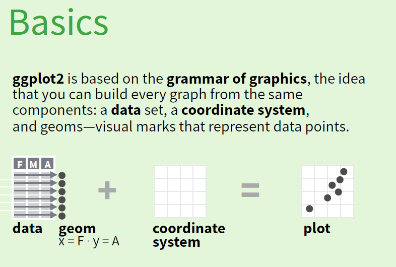

[figure not shown]

#### Barchart

Shows the distribution of a categorical variable

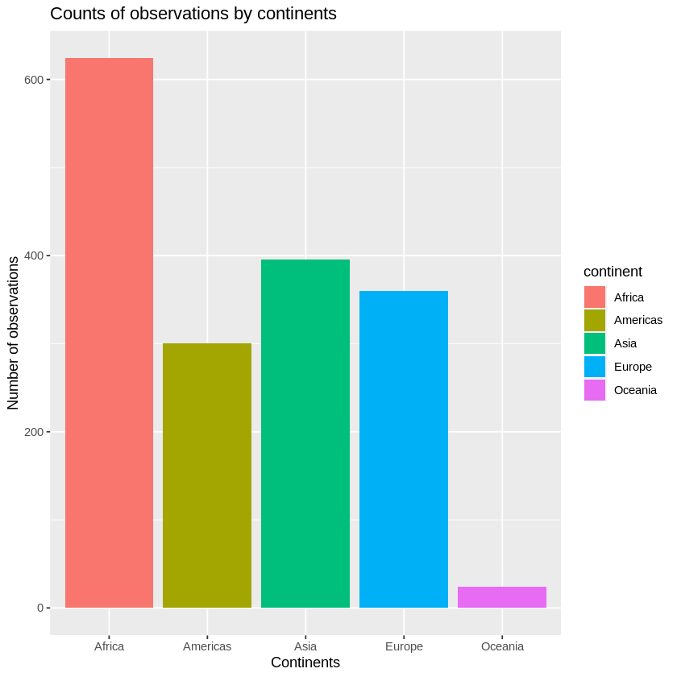

```r
# A barchart showing the number of observations in each continent

ggplot(data=countries, aes(x=continent, fill=continent))+
    geom_bar()+
    labs(title="Counts of observations by continents", x="Continents", y="Number of observations")
```

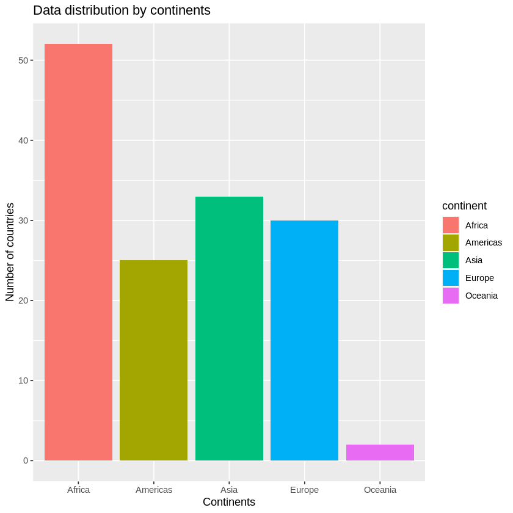

```r
# Modify count to measure the number of countries by dividing by 12

ggplot(data=countries, aes(x=continent, fill=continent))+
    geom_bar(aes(y=..count../12))+
    labs(title="Data distribution by continents", x="Continents", y="Number of countries")
```

#### Histograms

Visualizes the distribution of one quantitative variable

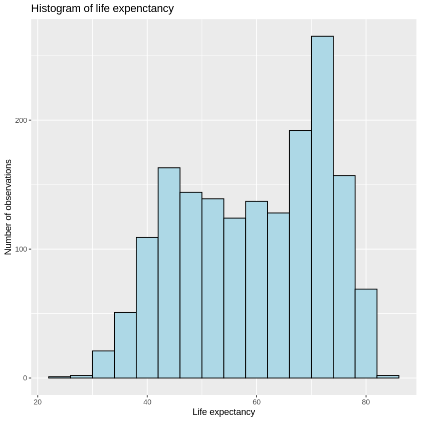

```r
# Visualize the distribution of life expectancy

ggplot(data=countries, aes(x=lifeExp)) +
    geom_histogram(binwidth=4,color="black", fill="lightblue") +
    labs(title="Histogram of life expenctancy ", x="Life expectancy", y="Number of observations")
```

#### Boxplots

Boxplots are used to compare distributions of one quantitative variable across multiple categories (a visualization alternative to density plots)

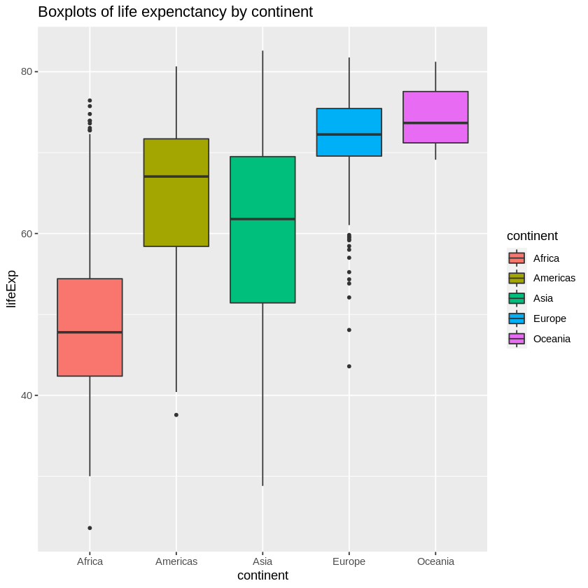

```r
# Comparing distribution of lifeExp variable by continent:

ggplot(data=countries, aes(x=continent, y=lifeExp, fill=continent))+
    geom_boxplot(outlier.size=1)+
    labs(title="Boxplots of life expenctancy by continent")
```

#### Scatterplot

Scatterplots show the relationship between two quantitative variables

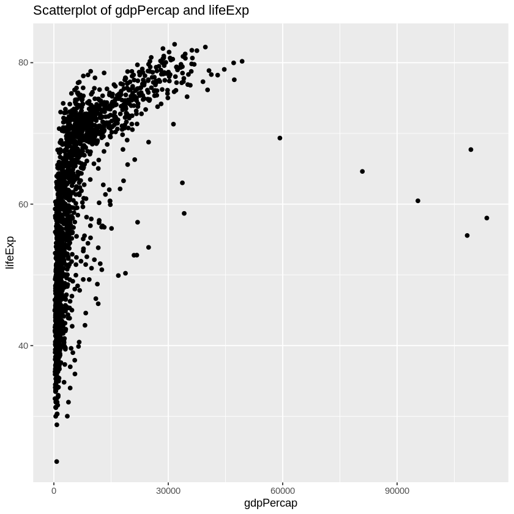

```r
# Make a scatterplot with gdpPercap and lifeExp variables

ggplot(data=countries, aes(x=gdpPercap, y=lifeExp))+
    geom_point()+
    labs(title="Scatterplot of gdpPercap and lifeExp")
```

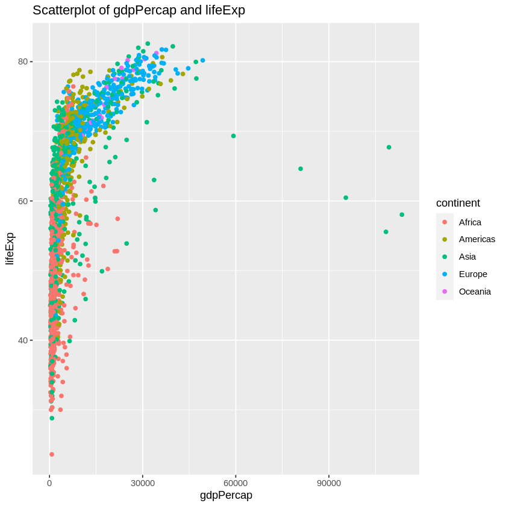

```r
# Add color to represent different continents

ggplot(data=countries, aes(x=gdpPercap, y=lifeExp))+
    geom_point(aes(color=continent))+
    labs(title="Scatterplot of gdpPercap and lifeExp")
```

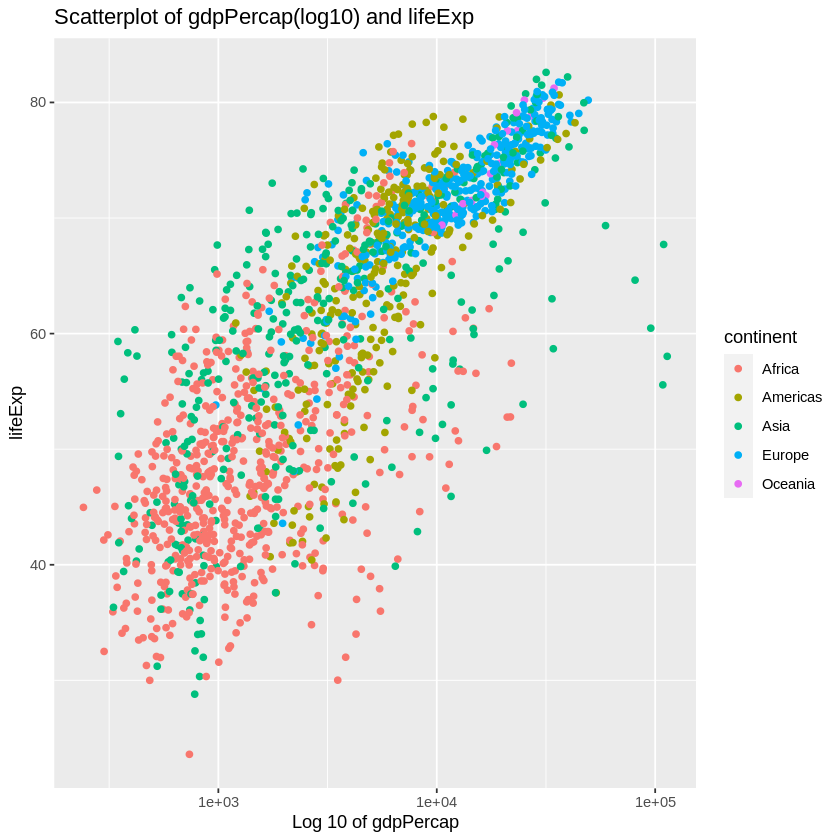

```r
# Transform the gdpPercap variable using a log10 scale

ggplot(data=countries, aes(x=gdpPercap, y=lifeExp))+
    geom_point(aes(color=continent))+
    scale_x_log10()+
    labs(title="Scatterplot of gdpPercap(log10) and lifeExp", x="Log 10 of gdpPercap")
```

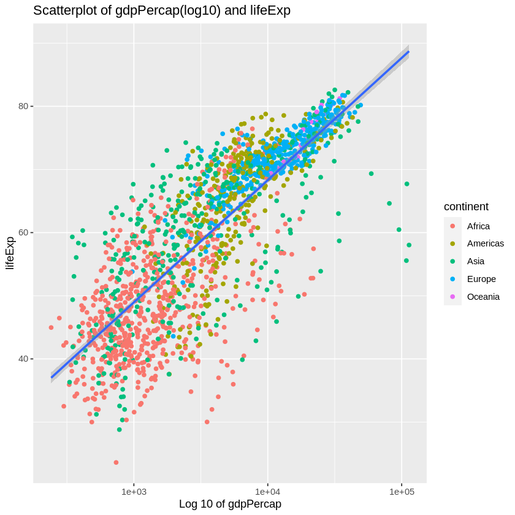

```r
# Add a best-fit line to the scatterplot

ggplot(data=countries, aes(x=gdpPercap, y=lifeExp))+
    geom_point(aes(color=continent))+
    geom_smooth(method="lm")+
    scale_x_log10()+
    labs(title="Scatterplot of gdpPercap(log10) and lifeExp", x="Log 10 of gdpPercap")
```

#### Piping in ggplot

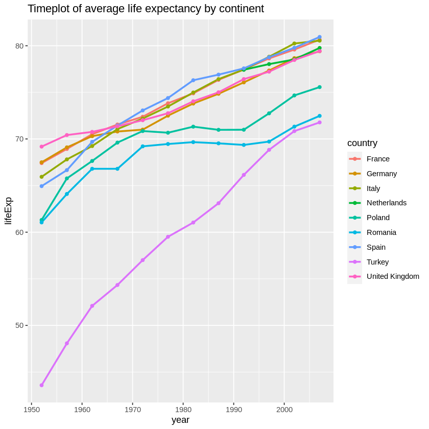

```r
# Make a timeplot of `lifeExp` for European countries with a population above 15m
countries %>%
    filter(continent=="Europe", pop>15000000) %>%
    ggplot(aes(x=year, y=lifeExp, color=country))+
    geom_line(size=1)+
    geom_point()+
    labs(title="Timeplot of average life expectancy by continent")
```

# Exercise #3

#### Make a timeplot of `gdpPercap` for countries in Americas with population above 20m

Hints:

- Use filter function to limit the selection of data to Americas, pop > 20000000
- Use ggplot, geom_point, and geom_line to make a graph

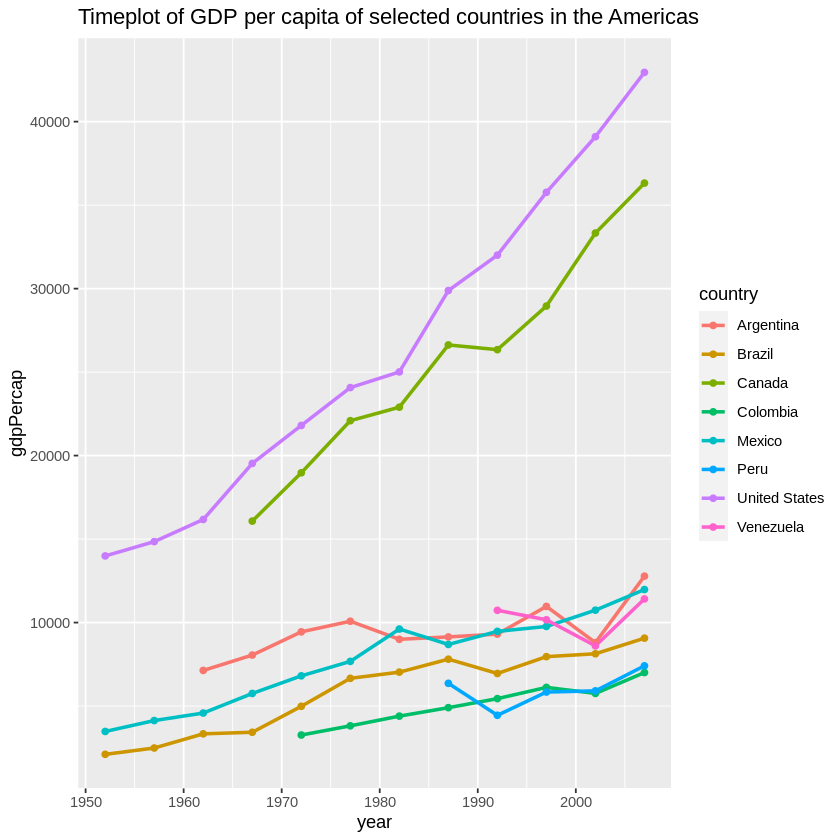

```r
# Answer

gdp_timeplot <- countries %>%
    filter(continent=="Americas", pop>20000000) %>%
    ggplot(aes(x=year, y=gdpPercap, color=country))+
    geom_line(size=1)+
    geom_point()+
    labs(title="Timeplot of GDP per capita of selected countries in the Americas")

gdp_timeplot
```

# Save produced graphs

```r
ggsave("gdp_timeplot.png", plot = gdp_timeplot, device="png", width = 8, height = 5)
```

# Save dataframe as CSV file

```r
write.csv(countries, file= "countries.csv")
```

# Questions?

Research Commons has a team of GAAs happy to help you analyze your data. Book a consultation online.

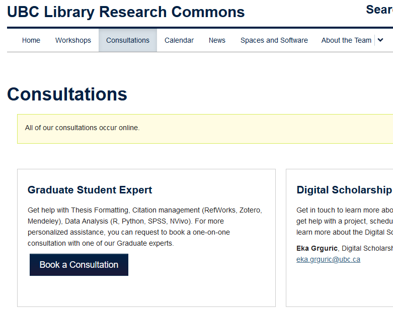